# Predict Bike Sharing Demand with AutoGluon Template

## Project: Predict Bike Sharing Demand with AutoGluon

This notebook is a template with each step that you need to complete for the project.

Please fill in your code where there are explicit `?` markers in the notebook. You are welcome to add more cells and code as you see fit.

Once you have completed all the code implementations, please export your notebook as a HTML file so the reviews can view your code. Make sure you have all outputs correctly outputted.

`File-> Export Notebook As... -> Export Notebook as HTML`

There is a writeup to complete as well after all code implememtation is done. Please answer all questions and attach the necessary tables and charts. You can complete the writeup in either markdown or PDF.

Completing the code template and writeup template will cover all of the rubric points for this project.

The rubric contains "Stand Out Suggestions" for enhancing the project beyond the minimum requirements. The stand out suggestions are optional. If you decide to pursue the "stand out suggestions", you can include the code in this notebook and also discuss the results in the writeup file.

## Step 1: Create an account with Kaggle

### Create Kaggle Account and download API key

Below is example of steps to get the API username and key. Each student will have their own username and key.

1. Open account settings.

2. Scroll down to API and click Create New API Token.

3. Open up `kaggle.json` and use the username and key.


## Step 2: Download the Kaggle dataset using the kaggle python library

### Open up Sagemaker Studio and use starter template

1. Notebook should be using a `ml.t3.medium` instance (2 vCPU + 4 GiB)
2. Notebook should be using kernal: `Python 3 (MXNet 1.8 Python 3.7 CPU Optimized)`

### Install packages

```python
!pip install -U pip
!pip install -U setuptools wheel
!pip install -U "mxnet<2.0.0" bokeh==2.0.1
!pip install autogluon --no-cache-dir
# Without --no-cache-dir, smaller aws instances may have trouble installing
```

[output not shown]

[output cut: 111 more lines]

[output not shown]

```python
!pip install kaggle
```

```
  Using cached kaggle-1.5.12-py3-none-any.whl
  Using cached python_slugify-6.1.2-py2.py3-none-any.whl (9.4 kB)
  Using cached text_unidecode-1.3-py2.py3-none-any.whl (78 kB)
WARNING: Running pip as the 'root' user can result in broken permissions and conflicting behaviour with the system package manager. It is recommended to use a virtual environment instead: https://pip.pypa.io/warnings/venv
```

### Setup Kaggle API Key

```python
# create the .kaggle directory and an empty kaggle.json file
!mkdir -p /root/.kaggle
!touch /root/.kaggle/kaggle.json
!chmod 600 /root/.kaggle/kaggle.json
```

```python
# Fill in your user name and key from creating the kaggle account and API token file
import json
kaggle_username = "lamiahasan"
kaggle_key = "2687495573d56ad3cbdcdb153843d5e9"

# Save API token the kaggle.json file
with open("/root/.kaggle/kaggle.json", "w") as f:
    f.write(json.dumps({"username": kaggle_username, "key": kaggle_key}))
```

### Download and explore dataset

### Go to the bike sharing demand competition and agree to the terms

```python
# Download the dataset, it will be in a .zip file so you'll need to unzip it as well.
!kaggle competitions download -c bike-sharing-demand
# If you already downloaded it you can use the -o command to overwrite the file
!unzip -o bike-sharing-demand.zip
```

```
bike-sharing-demand.zip: Skipping, found more recently modified local copy (use --force to force download)
Archive:  bike-sharing-demand.zip
  inflating: sampleSubmission.csv
  inflating: test.csv
  inflating: train.csv
```

```python
import pandas as pd
from autogluon.tabular import TabularPredictor
```

```python
# Create the train dataset in pandas by reading the csv
# Set the parsing of the datetime column so you can use some of the `dt` features in pandas later
train = pd.read_csv('train.csv',parse_dates=['datetime']) #change datetime datatype from object to datetime
#or we can use
#train["datetime"] = train.to_datetime(train["datetime"])
```

```python
train.head()
```

|  | datetime | season | holiday | workingday | weather | temp | atemp | humidity | windspeed | casual | registered | count |
| --- | --- | --- | --- | --- | --- | --- | --- | --- | --- | --- | --- | --- |
| 0 | 2011-01-01 00:00:00 | 1 | 0 | 0 | 1 | 9.84 | 14.395 | 81 | 0.0 | 3 | 13 | 16 |
| 1 | 2011-01-01 01:00:00 | 1 | 0 | 0 | 1 | 9.02 | 13.635 | 80 | 0.0 | 8 | 32 | 40 |
| 2 | 2011-01-01 02:00:00 | 1 | 0 | 0 | 1 | 9.02 | 13.635 | 80 | 0.0 | 5 | 27 | 32 |
| 3 | 2011-01-01 03:00:00 | 1 | 0 | 0 | 1 | 9.84 | 14.395 | 75 | 0.0 | 3 | 10 | 13 |
| 4 | 2011-01-01 04:00:00 | 1 | 0 | 0 | 1 | 9.84 | 14.395 | 75 | 0.0 | 0 | 1 | 1 |

```python
train.info()
```

```
<class 'pandas.core.frame.DataFrame'>
RangeIndex: 10886 entries, 0 to 10885
Data columns (total 12 columns):
 #   Column      Non-Null Count  Dtype
---  ------      --------------  -----
 0   datetime    10886 non-null  datetime64[ns]
 1   season      10886 non-null  int64
 2   holiday     10886 non-null  int64
 3   workingday  10886 non-null  int64
 4   weather     10886 non-null  int64
 5   temp        10886 non-null  float64
 6   atemp       10886 non-null  float64
 7   humidity    10886 non-null  int64
 8   windspeed   10886 non-null  float64
 9   casual      10886 non-null  int64
 10  registered  10886 non-null  int64
 11  count       10886 non-null  int64
dtypes: datetime64[ns](1), float64(3), int64(8)
memory usage: 1020.7 KB
```

```python
# Simple output of the train dataset to view some of the min/max/varition of the dataset features.
```

[output not shown]

```python
# Create the test pandas dataframe in pandas by reading the csv, remember to parse the datetime!
test =  pd.read_csv('test.csv',parse_dates=['datetime'])
test.head()
```

|  | datetime | season | holiday | workingday | weather | temp | atemp | humidity | windspeed |
| --- | --- | --- | --- | --- | --- | --- | --- | --- | --- |
| 0 | 2011-01-20 00:00:00 | 1 | 0 | 1 | 1 | 10.66 | 11.365 | 56 | 26.0027 |
| 1 | 2011-01-20 01:00:00 | 1 | 0 | 1 | 1 | 10.66 | 13.635 | 56 | 0.0000 |
| 2 | 2011-01-20 02:00:00 | 1 | 0 | 1 | 1 | 10.66 | 13.635 | 56 | 0.0000 |
| 3 | 2011-01-20 03:00:00 | 1 | 0 | 1 | 1 | 10.66 | 12.880 | 56 | 11.0014 |
| 4 | 2011-01-20 04:00:00 | 1 | 0 | 1 | 1 | 10.66 | 12.880 | 56 | 11.0014 |

```python
# Same thing as train and test dataset
submission = pd.read_csv('sampleSubmission.csv',parse_dates=['datetime'])
submission.head()
```

|  | datetime | count |
| --- | --- | --- |
| 0 | 2011-01-20 00:00:00 | 0 |
| 1 | 2011-01-20 01:00:00 | 0 |
| 2 | 2011-01-20 02:00:00 | 0 |
| 3 | 2011-01-20 03:00:00 | 0 |
| 4 | 2011-01-20 04:00:00 | 0 |

```python
train.isnull().values.any()
```

```
False
```

```python
train.isnull().values.any()
```

```
False
```

## Step 3: Train a model using AutoGluon’s Tabular Prediction

Requirements:

- We are prediting `count`, so it is the label we are setting.
- Ignore `casual` and `registered` columns as they are also not present in the test dataset.
- Use the `root_mean_squared_error` as the metric to use for evaluation.
- Set a time limit of 10 minutes (600 seconds).
- Use the preset `best_quality` to focus on creating the best model.

```python
predictor = TabularPredictor(
    label="count",
    eval_metric = 'root_mean_squared_error',
    verbosity=0,
    learner_kwargs={"ignored_columns": ["casual", "registered"]}
).fit(
    train_data=train,
    time_limit=600,
    presets="best_quality"
)
```

### Review AutoGluon's training run with ranking of models that did the best.

```python
predictor.fit_summary()
```

```
*** Summary of fit() ***
Estimated performance of each model:
                     model   score_val  pred_time_val    fit_time  pred_time_val_marginal  fit_time_marginal  stack_level  can_infer  fit_order
0      WeightedEnsemble_L3  -52.766075      11.246190  516.410949                0.000801           0.334859            3       True         15
1   RandomForestMSE_BAG_L2  -53.338560      10.306692  416.937931                0.615044          26.394191            2       True         12
2     ExtraTreesMSE_BAG_L2  -53.788112      10.317300  398.911686                0.625651           8.367945            2       True         14
3          LightGBM_BAG_L2  -55.068251       9.933854  414.649733                0.242205          24.105993            2       True         11
4          CatBoost_BAG_L2  -55.606515       9.762489  457.207961                0.070840          66.664221            2       True         13
5        LightGBMXT_BAG_L2  -60.305724      13.002170  443.161472                3.310521          52.617732            2       True         10
6    KNeighborsDist_BAG_L1  -84.125061       0.103599    0.030520                0.103599           0.030520            1       True          2
7      WeightedEnsemble_L2  -84.125061       0.104377    0.746200                0.000778           0.715680            2       True          9
8    KNeighborsUnif_BAG_L1 -101.546199       0.103044    0.036969                0.103044           0.036969            1       True          1
9   RandomForestMSE_BAG_L1 -116.544294       0.546011   10.664088                0.546011          10.664088            1       True          5
10    ExtraTreesMSE_BAG_L1 -124.588053       0.537367    4.950907                0.537367           4.950907            1       True          7
11         CatBoost_BAG_L1 -130.501314       0.115669  202.119611                0.115669         202.119611            1       True          6
12         LightGBM_BAG_L1 -131.054162       1.299188   28.165276                1.299188          28.165276            1       True          4
13       LightGBMXT_BAG_L1 -131.460909       6.592258   63.467682                6.592258          63.467682            1       True          3
14  NeuralNetFastAI_BAG_L1 -137.221557       0.394512   81.108688                0.394512          81.108688            1       True          8
Number of models trained: 15
Types of models trained:
{'WeightedEnsembleModel', 'StackerEnsembleModel_NNFastAiTabular', 'StackerEnsembleModel_KNN', 'StackerEnsembleModel_RF', 'StackerEnsembleModel_XT', 'StackerEnsembleModel_LGB', 'StackerEnsembleModel_CatBoost'}
Bagging used: True  (with 8 folds)
Multi-layer stack-ensembling used: True  (with 3 levels)
Feature Metadata (Processed):
(raw dtype, special dtypes):
('float', [])                : 3 | ['temp', 'atemp', 'windspeed']
('int', [])                  : 3 | ['season', 'weather', 'humidity']
('int', ['bool'])            : 2 | ['holiday', 'workingday']
('int', ['datetime_as_int']) : 5 | ['datetime', 'datetime.year', 'datetime.month', 'datetime.day', 'datetime.dayofweek']
Plot summary of models saved to file: AutogluonModels/ag-20221030_190904/SummaryOfModels.html
*** End of fit() summary ***
```

[output not shown]

[output cut: 139 more lines]

```
 0          15
 1          12
 2          14
 3          11
 4          13
 5          10
 6           2
 7           9
 8           1
 9           5
 10          7
 11          6
 12          4
 13          3
 14          8  }
```

### Create predictions from test dataset

```python
predictions = predictor.predict(test)
#predictions.head()
```

```python
predictions
```

```
0        22.634613
1        40.761917
2        44.765171
3        47.897354
4        50.622585
           ...
6488    157.099457
6489    157.116608
6490    151.356842
6491    147.571152
6492    147.461700
Name: count, Length: 6493, dtype: float32
```

#### NOTE: Kaggle will reject the submission if we don't set everything to be > 0.

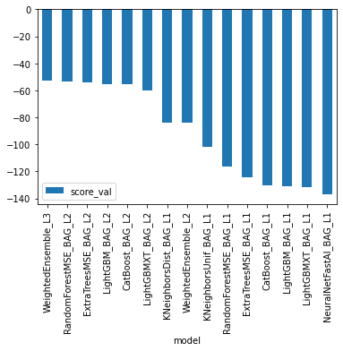

```python
predictor.leaderboard(silent=True).plot(kind='bar',x='model',y='score_val')
```

```python
# Describe the `predictions` series to see if there are any negative values
predictions.describe()
```

```
count    6493.000000
mean      100.864700
std        90.453880
min         2.925109
25%        20.691940
50%        62.772308
75%       170.538361
max       365.178711
Name: count, dtype: float64
```

```python
predictions.head()
```

[output not shown]

```python
# How many negative values do we have?
less_than_zero=[x for x in predictions if x<0]
len(less_than_zero)
```

```
0
```

```python
# Set them to zero
predictions.describe()
```

```
count    6493.000000
mean      100.864700
std        90.453880
min         2.925109
25%        20.691940
50%        62.772308
75%       170.538361
max       365.178711
Name: count, dtype: float64
```

### Set predictions to submission dataframe, save, and submit

```python
submission["count"] = predictions
# Round count column values
submission['count'] = submission['count'].apply(lambda x: round(x))
submission.to_csv("submission.csv", index=False)
```

```python
!kaggle competitions submit -c bike-sharing-demand -f submission.csv -m "first raw submission"
```

```
Successfully submitted to Bike Sharing Demand
```

#### View submission via the command line or in the web browser under the competition's page - `My Submissions`

```python
!kaggle competitions submissions -c bike-sharing-demand | tail -n +1 | head -n 6
```

```
fileName        date                 description           status    publicScore  privateScore
--------------  -------------------  --------------------  --------  -----------  ------------
submission.csv  2022-10-30 00:45:29  first raw submission  complete  1.81023      1.81023
submission.csv  2022-10-29 19:09:48  first raw submission  complete  1.81165      1.81165
```

#### Initial score of 1.81165

## Step 4: Exploratory Data Analysis and Creating an additional feature

- Any additional feature will do, but a great suggestion would be to separate out the datetime into hour, day, or month parts.

```
array([[<AxesSubplot:title={'center':'datetime'}>,
        <AxesSubplot:title={'center':'season'}>,
        <AxesSubplot:title={'center':'holiday'}>],
       [<AxesSubplot:title={'center':'workingday'}>,
        <AxesSubplot:title={'center':'weather'}>,
        <AxesSubplot:title={'center':'temp'}>],
       [<AxesSubplot:title={'center':'atemp'}>,
        <AxesSubplot:title={'center':'humidity'}>,
        <AxesSubplot:title={'center':'windspeed'}>],
       [<AxesSubplot:title={'center':'casual'}>,
        <AxesSubplot:title={'center':'registered'}>,
        <AxesSubplot:title={'center':'count'}>]], dtype=object)
```

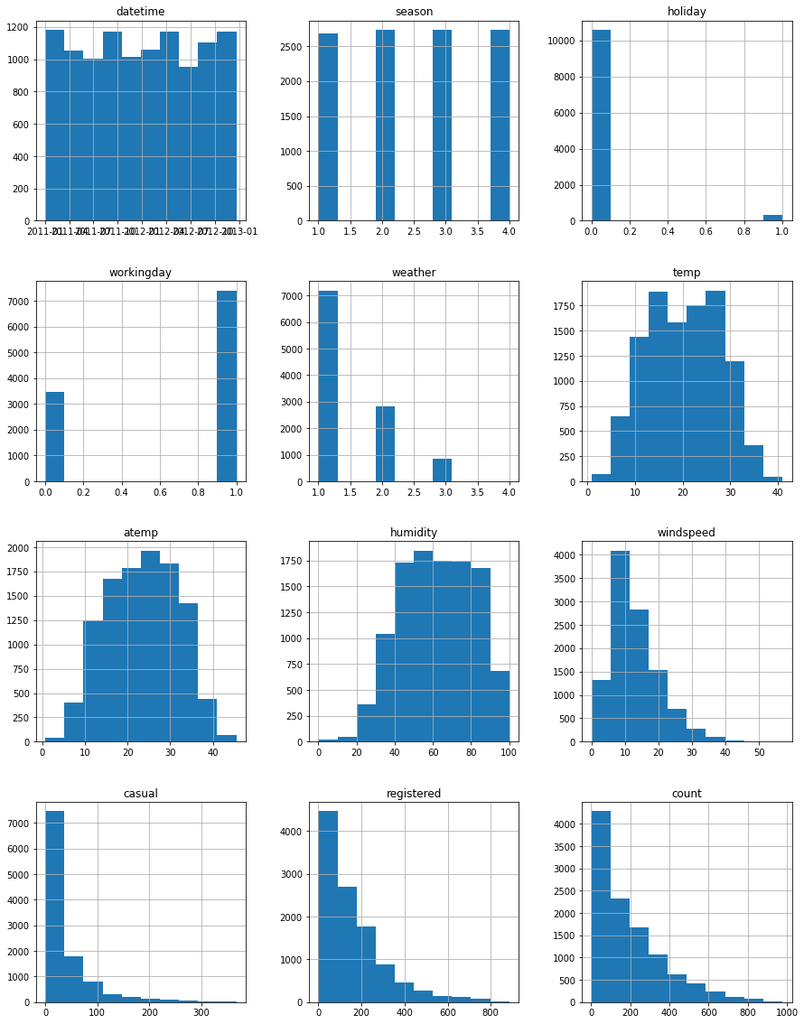

```python
# Create a histogram of all features to show the distribution of each one relative to the data.
#This is part of the exploritory data analysis
train.hist(figsize = (15,20))
```

```python
# create a new feature
#train['day'] = train['datetime'].dt.day
#train['month'] = train['datetime'].dt.month
#test['month'] = test['datetime'].dt.month
#train['year'] = train['datetime'].dt.year
```

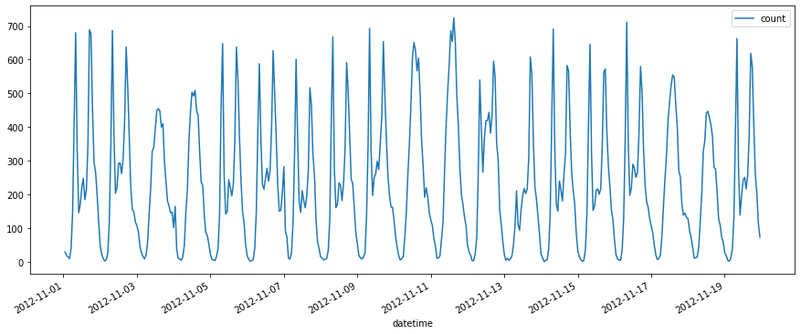

```python
# time series plot for a particular in one month
train.loc[(train.datetime > '2012-11-01') & (train.datetime < '2012-12-01')].plot(x='datetime', y='count', figsize=(15, 6));
```

```python
#train=train.drop('month',axis=1) #drop column named 'date'
#train.head()
#test=test.drop('month',axis=1) #drop column named 'date'
#test.head()
```

```python
# Seperate hour, day, month from datetime
train['hour'] = train['datetime'].dt.hour
train['day'] = train['datetime'].dt.day
train['month'] = train['datetime'].dt.month
test['hour'] = test['datetime'].dt.hour
test['day'] = test['datetime'].dt.day
test['month'] = test['datetime'].dt.month
```

```python
train=train.drop(['datetime'],axis=1)
test=test.drop(['datetime'],axis=1)
```

```python
train.head()
```

|  | season | holiday | workingday | weather | temp | atemp | humidity | windspeed | casual | registered | count | hour | day | month |
| --- | --- | --- | --- | --- | --- | --- | --- | --- | --- | --- | --- | --- | --- | --- |
| 0 | 1 | 0 | 0 | 1 | 9.84 | 14.395 | 81 | 0.0 | 3 | 13 | 16 | 0 | 1 | 1 |
| 1 | 1 | 0 | 0 | 1 | 9.02 | 13.635 | 80 | 0.0 | 8 | 32 | 40 | 1 | 1 | 1 |
| 2 | 1 | 0 | 0 | 1 | 9.02 | 13.635 | 80 | 0.0 | 5 | 27 | 32 | 2 | 1 | 1 |
| 3 | 1 | 0 | 0 | 1 | 9.84 | 14.395 | 75 | 0.0 | 3 | 10 | 13 | 3 | 1 | 1 |
| 4 | 1 | 0 | 0 | 1 | 9.84 | 14.395 | 75 | 0.0 | 0 | 1 | 1 | 4 | 1 | 1 |

```
array([[<AxesSubplot:title={'center':'season'}>,
        <AxesSubplot:title={'center':'holiday'}>,
        <AxesSubplot:title={'center':'workingday'}>,
        <AxesSubplot:title={'center':'weather'}>],
       [<AxesSubplot:title={'center':'temp'}>,
        <AxesSubplot:title={'center':'atemp'}>,
        <AxesSubplot:title={'center':'humidity'}>,
        <AxesSubplot:title={'center':'windspeed'}>],
       [<AxesSubplot:title={'center':'casual'}>,
        <AxesSubplot:title={'center':'registered'}>,
        <AxesSubplot:title={'center':'count'}>,
        <AxesSubplot:title={'center':'hour'}>],
       [<AxesSubplot:title={'center':'day'}>,
        <AxesSubplot:title={'center':'month'}>, <AxesSubplot:>,
        <AxesSubplot:>]], dtype=object)
```

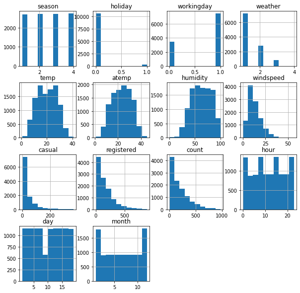

```python
train.hist(figsize=(10,10))
```

```python
#check for correlation
train.corr()
```

|  | season | holiday | workingday | weather | temp | atemp | humidity | windspeed | casual | registered | count | hour | day | month |
| --- | --- | --- | --- | --- | --- | --- | --- | --- | --- | --- | --- | --- | --- | --- |
| season | 1.000000 | 0.029368 | -0.008126 | 0.008879 | 0.258689 | 0.264744 | 0.190610 | -0.147121 | 0.096758 | 0.164011 | 0.163439 | -0.006546 | 0.001729 | 0.971524 |
| holiday | 0.029368 | 1.000000 | -0.250491 | -0.007074 | 0.000295 | -0.005215 | 0.001929 | 0.008409 | 0.043799 | -0.020956 | -0.005393 | -0.000354 | -0.015877 | 0.001731 |
| workingday | -0.008126 | -0.250491 | 1.000000 | 0.033772 | 0.029966 | 0.024660 | -0.010880 | 0.013373 | -0.319111 | 0.119460 | 0.011594 | 0.002780 | 0.009829 | -0.003394 |
| weather | 0.008879 | -0.007074 | 0.033772 | 1.000000 | -0.055035 | -0.055376 | 0.406244 | 0.007261 | -0.135918 | -0.109340 | -0.128655 | -0.022740 | -0.007890 | 0.012144 |
| temp | 0.258689 | 0.000295 | 0.029966 | -0.055035 | 1.000000 | 0.984948 | -0.064949 | -0.017852 | 0.467097 | 0.318571 | 0.394454 | 0.145430 | 0.015551 | 0.257589 |
| atemp | 0.264744 | -0.005215 | 0.024660 | -0.055376 | 0.984948 | 1.000000 | -0.043536 | -0.057473 | 0.462067 | 0.314635 | 0.389784 | 0.140343 | 0.011866 | 0.264173 |
| humidity | 0.190610 | 0.001929 | -0.010880 | 0.406244 | -0.064949 | -0.043536 | 1.000000 | -0.318607 | -0.348187 | -0.265458 | -0.317371 | -0.278011 | -0.011335 | 0.204537 |
| windspeed | -0.147121 | 0.008409 | 0.013373 | 0.007261 | -0.017852 | -0.057473 | -0.318607 | 1.000000 | 0.092276 | 0.091052 | 0.101369 | 0.146631 | 0.036157 | -0.150192 |
| casual | 0.096758 | 0.043799 | -0.319111 | -0.135918 | 0.467097 | 0.462067 | -0.348187 | 0.092276 | 1.000000 | 0.497250 | 0.690414 | 0.302045 | 0.014109 | 0.092722 |
| registered | 0.164011 | -0.020956 | 0.119460 | -0.109340 | 0.318571 | 0.314635 | -0.265458 | 0.091052 | 0.497250 | 1.000000 | 0.970948 | 0.380540 | 0.019111 | 0.169451 |
| count | 0.163439 | -0.005393 | 0.011594 | -0.128655 | 0.394454 | 0.389784 | -0.317371 | 0.101369 | 0.690414 | 0.970948 | 1.000000 | 0.400601 | 0.019826 | 0.166862 |
| hour | -0.006546 | -0.000354 | 0.002780 | -0.022740 | 0.145430 | 0.140343 | -0.278011 | 0.146631 | 0.302045 | 0.380540 | 0.400601 | 1.000000 | 0.001132 | -0.006818 |
| day | 0.001729 | -0.015877 | 0.009829 | -0.007890 | 0.015551 | 0.011866 | -0.011335 | 0.036157 | 0.014109 | 0.019111 | 0.019826 | 0.001132 | 1.000000 | 0.001974 |
| month | 0.971524 | 0.001731 | -0.003394 | 0.012144 | 0.257589 | 0.264173 | 0.204537 | -0.150192 | 0.092722 | 0.169451 | 0.166862 | -0.006818 | 0.001974 | 1.000000 |

```python
train.drop(['season'], axis=1, inplace=True)
```

```python
test.drop(['season'], axis=1, inplace=True)
```

```python
train.info()
```

```
<class 'pandas.core.frame.DataFrame'>
RangeIndex: 10886 entries, 0 to 10885
Data columns (total 13 columns):
 #   Column      Non-Null Count  Dtype
---  ------      --------------  -----
 0   holiday     10886 non-null  int64
 1   workingday  10886 non-null  int64
 2   weather     10886 non-null  int64
 3   temp        10886 non-null  float64
 4   atemp       10886 non-null  float64
 5   humidity    10886 non-null  int64
 6   windspeed   10886 non-null  float64
 7   casual      10886 non-null  int64
 8   registered  10886 non-null  int64
 9   count       10886 non-null  int64
 10  hour        10886 non-null  int64
 11  day         10886 non-null  int64
 12  month       10886 non-null  int64
dtypes: float64(3), int64(10)
memory usage: 1.1 MB
```

```python
train.isnull().values.any()
```

```
False
```

```python
test.isnull().values.any()
```

```
False
```

## Make category types for these so models know they are not just numbers

- AutoGluon originally sees these as ints, but in reality they are int representations of a category.
- Setting the dtype to category will classify these as categories in AutoGluon.

```python
#categorizing all numerical values


train["holiday"] = train["holiday"].astype('category')
train["workingday"] = train["workingday"].astype('category')
train["weather"] = train["weather"].astype('category')
train["hour"] = train["hour"].astype('category')
train["month"] = train["month"].astype('category')
train["temp"] = train["temp"].astype('category')
train["atemp"] = train["atemp"].astype('category')
train["humidity"] = train["humidity"].astype('category')
train["windspeed"] = train["windspeed"].astype('category')
train["day"] = train["day"].astype('category')




test["holiday"] = test["holiday"].astype('category')
test["workingday"] = test["workingday"].astype('category')
test["weather"] = test["weather"].astype('category')
test["hour"] = test["hour"].astype('category')
test["month"] = test["month"].astype('category')
test["temp"] = test["temp"].astype('category')
test["atemp"] = test["atemp"].astype('category')
test["humidity"] = test["humidity"].astype('category')
test["windspeed"] = test["windspeed"].astype('category')
test["day"] = test["day"].astype('category')
```

```python
# View are new feature
test.info()
```

```
<class 'pandas.core.frame.DataFrame'>
RangeIndex: 6493 entries, 0 to 6492
Data columns (total 10 columns):
 #   Column      Non-Null Count  Dtype
---  ------      --------------  -----
 0   holiday     6493 non-null   category
 1   workingday  6493 non-null   category
 2   weather     6493 non-null   category
 3   temp        6493 non-null   category
 4   atemp       6493 non-null   category
 5   humidity    6493 non-null   category
 6   windspeed   6493 non-null   category
 7   hour        6493 non-null   category
 8   day         6493 non-null   category
 9   month       6493 non-null   category
dtypes: category(10)
memory usage: 73.4 KB
```

```python
train.info()
```

```
<class 'pandas.core.frame.DataFrame'>
RangeIndex: 10886 entries, 0 to 10885
Data columns (total 13 columns):
 #   Column      Non-Null Count  Dtype
---  ------      --------------  -----
 0   holiday     10886 non-null  category
 1   workingday  10886 non-null  category
 2   weather     10886 non-null  category
 3   temp        10886 non-null  category
 4   atemp       10886 non-null  category
 5   humidity    10886 non-null  category
 6   windspeed   10886 non-null  category
 7   casual      10886 non-null  int64
 8   registered  10886 non-null  int64
 9   count       10886 non-null  int64
 10  hour        10886 non-null  category
 11  day         10886 non-null  category
 12  month       10886 non-null  category
dtypes: category(10), int64(3)
memory usage: 371.8 KB
```

```python
#drop casual, registered since they aren't in the test dataset
train.drop(['registered','casual'], axis=1, inplace=True)
```

```
array([[<AxesSubplot:title={'center':'count'}>]], dtype=object)
```

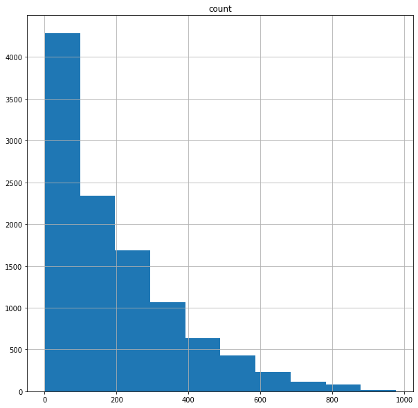

```python
# View histogram of all features again now with the hour feature
train.hist(figsize=(10,10))
```

## Step 5: Rerun the model with the same settings as before, just with more features

```python
predictor_new_features = TabularPredictor(
    label="count",
    verbosity=0,
    eval_metric = 'root_mean_squared_error',
    learner_kwargs={"ignored_columns": ["casual", "registered"]}
).fit(
    train_data=train,
    time_limit=600,
    presets="best_quality"
)
```

```python
predictor_new_features.fit_summary()
```

[output not shown]

[output not shown]

[output cut: 151 more lines]

```
 1          14
 2          13
 3          15
 4          11
 5          12
 6           9
 7          10
 8           4
 9           3
 10          6
 11          5
 12          7
 13          2
 14          8
 15          1  }
```

```python
predictions = predictor_new_features.predict(test)
```

```python
# Remember to set all negative values to zero
less_than_zero=[x for x in predictions if x<0]
len(less_than_zero)
```

```
45
```

```python
predictions = predictions.clip(lower=0)
```

```python
#make sure
less_than_zero=[x for x in predictions if x<0]
len(less_than_zero)
```

```
0
```

```python
# Same submitting predictions
submission_new_features = pd.read_csv('sampleSubmission.csv', parse_dates=['datetime'])
submission_new_features["count"] = predictions
# Round count column values
submission_new_features['count'] = submission_new_features['count'].apply(lambda x: round(x))
submission_new_features.to_csv("submission_new_features.csv", index=False)
```

```python
!kaggle competitions submit -c bike-sharing-demand -f submission_new_features.csv -m "new features"
```

```
Successfully submitted to Bike Sharing Demand
```

```python
!kaggle competitions submissions -c bike-sharing-demand | tail -n +1 | head -n 6
```

```
fileName                     date                 description           status    publicScore  privateScore
---------------------------  -------------------  --------------------  --------  -----------  ------------
submission_new_features.csv  2022-10-30 01:29:59  new features          complete  0.57651      0.57651
submission.csv               2022-10-30 00:45:29  first raw submission  complete  1.81023      1.81023
submission.csv               2022-10-29 19:09:48  first raw submission  complete  1.81165      1.81165
```

#### New Score of 0.57651

## Step 6: Hyper parameter optimization

- There are many options for hyper parameter optimization.
- Options are to change the AutoGluon higher level parameters or the individual model hyperparameters.
- The hyperparameters of the models themselves that are in AutoGluon. Those need the `hyperparameter` and `hyperparameter_tune_kwargs` arguments.

```python
import autogluon.core as ag

gbm_options = {
    'num_boost_round': 100,
    'num_leaves': ag.space.Int(lower=26, upper=66, default=36),
    'objective':'huber',
    'num_iterations':200
}

hyperparameters={'GBM': gbm_options,
                 'NN': {},
                 'KNN':{'n_neighbors':4,'weights':'distance','algorithm':'brute'},
                 'XGB': {'objective':'reg:pseudohubererror','eval_metric' :'rmse' },
                 'RF': {'n_estimators':200,'criterion':['gini','entropy','log_loss']}
                }

#hyperparameter_tune_kwargs= {'num_trials': 1024, 'searcher': 'random'}

predictor_new_hpo = TabularPredictor(label="count",
    verbosity=0,
    eval_metric='root_mean_squared_error',
    learner_kwargs={"ignored_columns": ["casual", "registered"]}).fit(train_data=train,
    time_limit=600,
    presets="best_quality",
    hyperparameters=hyperparameters)
```

[output not shown]

```python
predictor_new_hpo.fit_summary()
```

[output not shown]

[output not shown]

[output cut: 38 more lines]

```
 1                0.000853           0.217813            2       True
 2                5.713587         167.280293            1       True
 3                0.155597          18.329682            2       True
 4                1.813389         157.212305            2       True
 5                1.728807         140.427550            1       True
 6               19.959199           0.010719            1       True

    fit_order
 0          7
 1          4
 2          2
 3          5
 4          6
 5          3
 6          1  }
```

```python
predictions = predictor_new_hpo.predict(test)
```

```python
# Remember to set all negative values to zero
predictions = predictions.clip(lower=0)
```

```python
#make sure
less_than_zero=[x for x in predictions if x<0]
len(less_than_zero)
```

```
0
```

```python
# load submitting csv
submission_new_hpo = pd.read_csv('sampleSubmission.csv', parse_dates=['datetime'])
submission_new_hpo["count"] = predictions
# Round count column values
submission_new_hpo['count'] = submission_new_hpo['count'].apply(lambda x: round(x))
submission_new_hpo.to_csv("submission_new_hpo.csv", index=False)
```

```python
!kaggle competitions submit -c bike-sharing-demand -f submission_new_hpo.csv -m "new features with hyperparameters"
```

```
Successfully submitted to Bike Sharing Demand
```

```python
!kaggle competitions submissions -c bike-sharing-demand | tail -n +1 | head -n 10
```

```
fileName                     date                 description                        status    publicScore  privateScore
---------------------------  -------------------  ---------------------------------  --------  -----------  ------------
submission_new_hpo.csv       2022-10-30 18:58:41  new features with hyperparameters  complete  0.55532      0.55532
submission_new_hpo.csv       2022-10-30 16:52:01  new features with hyperparameters  complete  0.64701      0.64701
submission_new_hpo.csv       2022-10-30 15:59:50  new features with hyperparameters  complete  0.62840      0.62840
submission_new_hpo.csv       2022-10-30 03:57:58  new features with hyperparameters  complete  0.63367      0.63367
submission_new_features.csv  2022-10-30 01:29:59  new features                       complete  0.57651      0.57651
submission.csv               2022-10-30 00:45:29  first raw submission               complete  1.81023      1.81023
submission.csv               2022-10-29 19:09:48  first raw submission               complete  1.81165      1.81165
```